# Introduction to fluxfinder

The `fluxfinder` package provides functions to parse static-chamber greenhouse gas measurement files generated by a variety of instruments; compute flux rates using multi-observation metadata; and generate diagnostic metrics and plots. It’s designed to be easy to integrate into scientific workflows.

## Load sample data

```r
library(fluxfinder)

# Data from a LI-7810
f <- system.file("extdata/TG10-01087.data", package = "fluxfinder")
dat <- ffi_read_LI7810(f)
```

```
#> TG10-01087.data: read 507 rows of TG10-01087 data, 2022-10-27 10:35:42 to 2022-10-27 10:44:08 EST
```

```r
# Note that the fluxfinder read functions print some info after reading
# Set "options(fluxfinder.quiet = TRUE)" to suppress such messages

# Look at a subset of the data; the full data frame has 500+ rows and 25 columns
dat[1:6, 1:9]
```

```
#>   DATAH    SECONDS NANOSECONDS  NDX DIAG REMARK      H2O      CO2      CH4
#> 1  DATA 1666884942   313442945 4509    0     NA 12500.35 458.8612 2068.000
#> 2  DATA 1666884943   313442945 4513    0     NA 12449.87 458.1066 2069.830
#> 3  DATA 1666884944   313442945 4517    0     NA 12418.81 458.7320 2071.540
#> 4  DATA 1666884945   313442945 4521    0     NA 12429.65 458.8037 2071.960
#> 5  DATA 1666884946   313442945 4525    0     NA 12439.89 458.2824 2069.660
#> 6  DATA 1666884947   313442945 4529    0     NA 12429.37 456.9340 2066.544
```

The data frame returned by `ffi_read_LI7810` is all data from the raw LI-7810 file, except that `TIMESTAMP`, `TZ` (time zone of the timestamps), `SN` (serial number), and `MODEL` columns have been added.

The analyzer data is basically a stream of measured greenhouse gas concentrations:

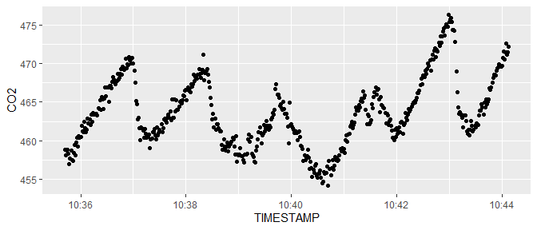

```r
library(ggplot2)
ggplot(dat, aes(TIMESTAMP, CO2)) + geom_point()
```

## Match with metadata

For these data to be useful, we need to associate them with *metadata* about the measurements: when they were started, how long they lasted, plot/treatment/collar information, etc.

```r
# Accompanying metadata
md <- system.file("extdata/TG10-01087-metadata.csv", package = "fluxfinder")
metadat <- read.csv(md)

print(metadat)
```

```
#>         Date Start_time Plot Obs_length
#> 1 2022-10-27   10:35:30    A         60
#> 2 2022-10-27   10:37:15    B         60
#> 3 2022-10-27   10:39:00    C         60
#> 4 2022-10-27   10:40:30    D         60
#> 5 2022-10-27   10:42:00    E         60
#> 6 2022-10-27   10:43:30    F         60
#> 7 2022-10-27   11:00:00    G         60
```

**Important note**: in this sample metadata, our measurement identified is labeled `Plot`, but this could be named, and refer to, anything: bottle, sample, collar, etc. It’s simply an identifier for *this* measurement, i.e. this row.

The `ffi_metadata_match` function matches up the data with metadata, using the `TIMESTAMP` column that `ffi_read_LI7810` helpfully created when it read the data file.

```r
dat$metadat_row <- ffi_metadata_match(
  data_timestamps = dat$TIMESTAMP,
  start_dates = metadat$Date,
  start_times = metadat$Start_time,
  obs_lengths = metadat$Obs_length + 10) # 10 is expected dead band length
```

```
#> 1 entry had no timestamp matches!
```

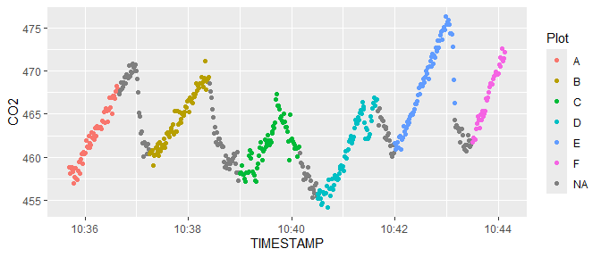

```r
# Note that ffi_metadata_match() warns us that one metadata row didn't match any data

# Based on the row match information, add a "Plot" column to the data
dat$Plot <- metadat$Plot[dat$metadat_row]
metadat$metadat_row <- seq_len(nrow(metadat))

# ...and plot
p <- ggplot(dat, aes(TIMESTAMP, CO2, color = Plot)) + geom_point()
print(p)
```

Some of these are clearly not correct–the measurement time seems to be shorter then 60 seconds for the C, D, and E plots:

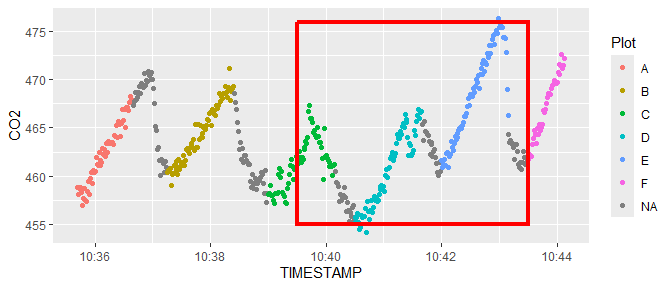

In real life we’d want to correct the faulty metadata at its source. Here, we’ll just change the values programmatically and re-match:

```r
metadat$Obs_length[3:5] <- c(30, 45, 45)
dat$metadat_row <- ffi_metadata_match(
  data_timestamps = dat$TIMESTAMP,
  start_dates = metadat$Date,
  start_times = metadat$Start_time,
  obs_lengths = metadat$Obs_length + 10)
```

```
#> 1 entry had no timestamp matches!
```

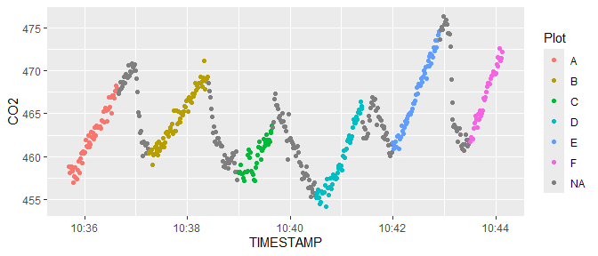

```r
dat$Plot <- metadat$Plot[dat$metadat_row]

p %+% dat
```

That looks better!

## Unit conversion

We’d like our final units to be in µmol/m2/s, and so need to do some unit conversion. (This can happen either before or after flux computation, below.) The package provides `ffi_ppm_to_umol()` and `ffi_ppb_to_nmol()` functions that perform this conversion using the [Ideal Gas Law](https://en.wikipedia.org/wiki/Ideal_gas_law).

```r
dat$CO2_umol <- ffi_ppm_to_umol(dat$CO2,
                                volume = 0.1, # m3
                                temp = 24)    # degrees C
```

```
#> Assuming atm = 101325 Pa
#> Using R = 8.31446261815324 m3 Pa K-1 mol-1
```

```r
# See the message: because we didn't provide the 'atm' parameter,
# ffi_ppm_to_umol assumed standard pressure.

# Also normalize by ground area (0.16 m2 in this example)
dat$CO2_umol_m2 <- dat$CO2_umol / 0.16
```

Note that in the example above we’re using a **constant system volume and measurement ground area**. If that’s not the case, there should be a column in the metadata providing the changing values (e.g. giving volume in m<sup>3</sup>) for each measurement. Then after calling `ffi_metadata_match()`, merge the data and metadata and pass the appropriate column to `ffi_ppm_to_umol()`. Here’s an example:

```r
# Let's say volume varies by measurement; this can happen if the chamber
# height changes depending on the ground vegetation in each plot
metadat$Volume <- c(0.1, 0.2, 0.1, 0.1, 0.3, 0.1, 0.1)

# Merge the data and metadata
dat_changing_vol <- merge(dat, metadat[c("Plot", "Volume")], by = "Plot", all.x = TRUE)

# Unit conversion as above, but using the changing volume information:
dat_changing_vol$CO2_umol <- ffi_ppm_to_umol(dat_changing_vol$CO2,
                                             volume = dat_changing_vol$Volume,
                                             temp = 24)
```

```
#> Assuming atm = 101325 Pa
#> Using R = 8.31446261815324 m3 Pa K-1 mol-1
```

```r
# We still have constant ground area in this example
dat_changing_vol$CO2_umol_m2 <- dat_changing_vol$CO2_umol / 0.16

# Relative to the previous constant-volume example, our area-normalized
# amounts (µmol) have now increased for plots B and E because
# of their larger volumes:
aggregate(CO2_umol_m2 ~ Plot, data = dat, FUN = mean)
```

```
#>   Plot CO2_umol_m2
#> 1    A    11855.81
#> 2    B    11908.15
#> 3    C    11787.88
#> 4    D    11776.09
#> 5    E    11974.30
#> 6    F    11976.25
```

```r
aggregate(CO2_umol_m2 ~ Plot, data = dat_changing_vol, FUN = mean)
```

```
#>   Plot CO2_umol_m2
#> 1    A    11855.81
#> 2    B    23816.30
#> 3    C    11787.88
#> 4    D    11776.09
#> 5    E    35922.89
#> 6    F    11976.25
```

## Compute fluxes

The `ffi_compute_fluxes` function provides a general-purpose tool for computing fluxes from concentration time series, as well as associated QA/QC information. It returns statistics for four types of models: *linear*, *robust linear*, *polynomial*, and *HM81*, an exponential model derived from diffusion theory, following [Hutchinson and Mosier (1981)](http://dx.doi.org/10.2136/sssaj1981.03615995004500020017x).

For the robust linear regression model only, a logical value converged.

```r
fluxes <- ffi_compute_fluxes(dat,
                             group_column = "Plot",
                             time_column = "TIMESTAMP",
                             gas_column = "CO2_umol_m2",
                             dead_band = 10)
```

```
#> NOTE: HM81_flux.estimate is not NA, implying nonlinear data
#> NOTE: HM81_flux.estimate is not NA, implying nonlinear data
#> NOTE: HM81_flux.estimate is not NA, implying nonlinear data
```

```r
#Here we use a constant dead band value, but this can also vary by group; see the documentation


# By default, ffi_compute_fluxes returns a data.frame with one row per
# grouping variable value (i.e., per measurement). The first column is the
# group label; the second is the average value of the `time_column`;
# and the rest of the columns are fit statistics for a linear fit of
# concentration as a function of time, along with information about polynomial
# and robust-linear fits. See ?ffi_compute_fluxes for more details.
names(fluxes)
```

```
#>  [1] "Plot"               "TIMESTAMP"          "HM81_AIC"
#>  [4] "HM81_RMSE"          "HM81_flux.estimate" "HM81_p.value"
#>  [7] "HM81_r.squared"     "lin_AIC"            "lin_RMSE"
#> [10] "lin_flux.estimate"  "lin_flux.std.error" "lin_int.estimate"
#> [13] "lin_int.std.error"  "lin_p.value"        "lin_r.squared"
#> [16] "poly_AIC"           "poly_RMSE"          "poly_r.squared"
#> [19] "rob_AIC"            "rob_RMSE"           "rob_converged"
#> [22] "rob_flux.estimate"  "rob_flux.std.error" "TIMESTAMP_min"
#> [25] "TIMESTAMP_max"
```

```r
# For clarity, print out only a subset of the columns
fluxes[c("Plot", "TIMESTAMP", "lin_r.squared", "lin_flux.estimate", "HM81_flux.estimate")]
```

```
#>   Plot           TIMESTAMP lin_r.squared lin_flux.estimate HM81_flux.estimate
#> 1    A 2022-10-27 10:36:15     0.9486012          4.862042           4.794940
#> 2    B 2022-10-27 10:37:54     0.9467074          4.024164                 NA
#> 3    C 2022-10-27 10:39:24     0.6002940          3.967315           4.483758
#> 4    D 2022-10-27 10:41:02     0.9560099          6.463719                 NA
#> 5    E 2022-10-27 10:42:32     0.9825172          6.680752                 NA
#> 6    F 2022-10-27 10:43:54     0.9512708          7.231148           6.261085
```

Note that the `fluxes` extract printed above has one row per `Plot`, the grouping variable; the mean `TIMESTAMP` of the group; model statistics such as `lin_r.squared`; and the flux estimate. The final column, `HM81_flux.estimate` is only numeric (i.e., not `NA`) when the data show evidence of a saturating curvature. So in this case we might want to examine more carefully the data from plots A, C, and F.

Plotting our computed fluxes:

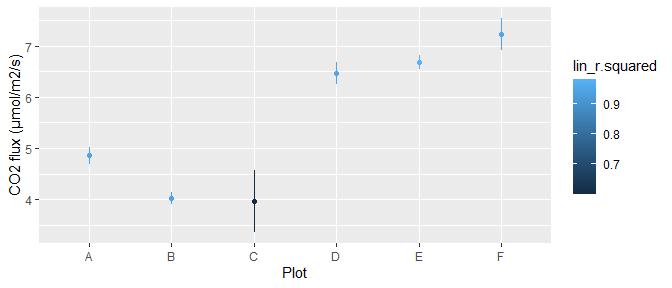

```r
ggplot(fluxes, aes(Plot, lin_flux.estimate, color = lin_r.squared)) +
  geom_point() +
  geom_linerange(aes(ymin = lin_flux.estimate - lin_flux.std.error,
                     ymax = lin_flux.estimate + lin_flux.std.error)) +
  ylab("CO2 flux (µmol/m2/s)")
```

We might want to check whether the robust-linear slope diverges from the linear fit slope, suggesting influential outliers, or whether the polynomial R<sup>2</sup> is much larger, potentially indicating curvature of the observations due to e.g. diffusion limitations.

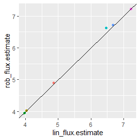

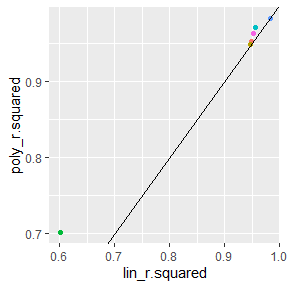

```r
ggplot(fluxes, aes(lin_flux.estimate, rob_flux.estimate, color = Plot)) +
  geom_point() + geom_abline() + theme(legend.position = "none")
ggplot(fluxes, aes(lin_r.squared, poly_r.squared, color = Plot)) +
  geom_point() + geom_abline() + theme(legend.position="none")
```

The plot C (green) data have more scatter, and thus lower R<sup>2</sup> values and higher uncertainty on the computed flux, but there’s no strong evidence of nonlinearity or outlier problems (although see note above about the `HM81_estimate` field).

## A clearly nonlinear case

In our experience, static-chamber fluxes are frequently linear ([Forbrich et al. 2010](https://doi.org/10.1016/j.soilbio.2009.12.004)) even though molecular diffusion means that chamber feedbacks will inevitably lead to curvilinear (saturating) behavior over time ([Pedersen et al. 2010](https://doi.org/10.1111/j.1365-2389.2010.01291.x)).

Still, how does one use `fluxfinder` to diagnose and work with nonlinear data?

Let’s use R’s built-in `Puromycin` dataset (simply because it exhibits saturating behavior; it’s unrelated to greenhouse gases) as an example:

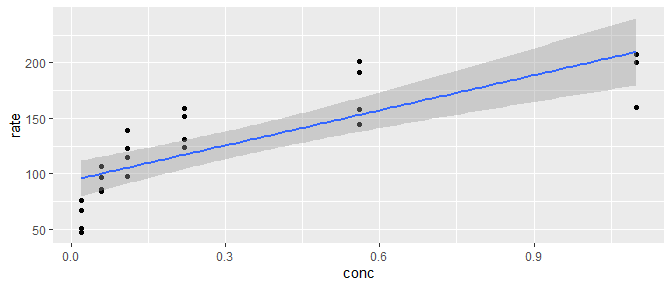

```r
ggplot(Puromycin, aes(conc, rate)) + geom_point() + geom_smooth(method = "lm")
```

Visually, we can see that a linear model will not be appropriate in this case.

```r
ffi_compute_fluxes(Puromycin,
                   group_column = NULL,
                   time_column = "conc",
                   gas_column = "rate")
```

```
#> NOTE: HM81_flux.estimate is not NA, implying nonlinear data
#>        conc HM81_AIC HM81_RMSE HM81_flux.estimate HM81_p.value HM81_r.squared
#> 1 0.3121739 200.9997  17.56084           246.1399 9.406055e-11      0.8696062
#>    lin_AIC lin_RMSE lin_flux.estimate lin_flux.std.error lin_int.estimate
#> 1 223.7834 28.81711           105.398            16.9191         96.03154
#>   lin_int.std.error  lin_p.value lin_r.squared poly_AIC poly_RMSE
#> 1          7.780867 3.525876e-06     0.6488706  205.746  18.76394
#>   poly_r.squared  rob_AIC rob_RMSE rob_converged rob_flux.estimate
#> 1      0.8653059 223.8119 24.79301          TRUE          106.2137
#>   rob_flux.std.error conc_min conc_max
#> 1           20.65072     0.02      1.1
```

From the diagnostics returned by `ffi_compute_fluxes`:

- `HM81_flux.estimate` is not `NA`, which only occurs with saturating behavior;
- The `lin_AIC` (223.783) and `rob_AIC` (223.812) [Akaike information criterion](https://en.wikipedia.org/wiki/Akaike_information_criterion) values are similar, so no indication of influential outliers;
- The `lin_r.squared` (0.649) and `poly_r.squared` (0.865) values are *very* different, suggesting a failure of the linear model;
- The [root mean square error](https://en.wikipedia.org/wiki/Root_mean_square_deviation) (RMSE) of the linear model is much higher than the other models’ values;
- The `HM81_r.squared` (0.87) and `HM81_AIC` (201) are considerably higher and lower, respectively, than the linear model.

All of these metrics point to a common conclusion: a linear model is *not* appropriate for these data. If these were real data, we should use the `HM81_flux.estimate` value as our flux estimate.

## Conclusion

This vignette covered `fluxfinder` basics: loading data and metadata, matching the two, performing unit conversion, computing fluxes, and some basic QA/QC. The test data we worked above could be fit well by linear model, but for many reasons this might not always be true; see the vignette on integrating with the gasfluxes package for guidance on using more sophisticated model-fitting routines.